# Titanic Survival Exploration

### by Wenzhe Ding

In 1912, the ship RMS Titanic struck an iceberg on its maiden voyage and sank, resulting in the deaths of most of its passengers and crew. In this project, we explore a subset of the [RMS Titanic passenger dataset](https://www.kaggle.com/c/titanic/data) to determine which features best predict whether someone survived or did not survive.

- Data Exploration
  - Survival Rate
  - Females vs. Males
  - Survival Rate
  - Age Group
  - Children vs. Others
  - Ticket Price
  - Ticket Class
  - Families vs. Singletons
- Making Predictionsl
  - Accuracy Score
  - Model 1
  - Model 2
  - Final Model
- Conclusion
  - Limitation
  - Prediction

```python
import pandas as pd
import numpy as np
import matplotlib.pyplot as plt
from IPython.display import display # Allows the use of display() for DataFrames

# Import supplementary visualizations code visuals.py
import visuals as vs

# Pretty display for notebooks
%matplotlib inline
from statsmodels.graphics.mosaicplot import mosaic
import warnings
warnings.filterwarnings('ignore')
```

## Data Exploration

[ go back to the top ]

The questions that we are going to explore in this section are:

- What is the survival rate of this disaster?
- Are females more likely to survive males?
- Is there a certain age group more likely to survive other age groups?
- Are childern and mothers more likely to be survived than others?
- Did people pay higher fare tend to survive?
- Are there difference of survival rate between differnt ticket classes?
- who will more likely to survive, families or sigletons?

After the exploratary data analysis with the above questions, we will conclude with summary of limitations and findings learning from this dataset .

```python
data = pd.read_csv('titanic_data.csv')
print("Number of data points: ",len(data))
```

```
Number of data points:  891
```

```python
print("Data fields are: ", data.columns)
```

```
Data fields are:  Index(['PassengerId', 'Survived', 'Pclass', 'Name', 'Sex', 'Age', 'SibSp',
       'Parch', 'Ticket', 'Fare', 'Cabin', 'Embarked'],
      dtype='object')
```

We have a total of 891 data points and 12 columns.

```python
print("The first few entries of the RMS Titanic data :")
data.head(5)
```

```
The first few entries of the RMS Titanic data :
```

|  | PassengerId | Survived | Pclass | Name | Sex | Age | SibSp | Parch | Ticket | Fare | Cabin | Embarked |
| --- | --- | --- | --- | --- | --- | --- | --- | --- | --- | --- | --- | --- |
| 0 | 1 | 0 | 3 | Braund, Mr. Owen Harris | male | 22.0 | 1 | 0 | A/5 21171 | 7.2500 | NaN | S |
| 1 | 2 | 1 | 1 | Cumings, Mrs. John Bradley (Florence Briggs Th... | female | 38.0 | 1 | 0 | PC 17599 | 71.2833 | C85 | C |
| 2 | 3 | 1 | 3 | Heikkinen, Miss. Laina | female | 26.0 | 0 | 0 | STON/O2. 3101282 | 7.9250 | NaN | S |
| 3 | 4 | 1 | 1 | Futrelle, Mrs. Jacques Heath (Lily May Peel) | female | 35.0 | 1 | 0 | 113803 | 53.1000 | C123 | S |
| 4 | 5 | 0 | 3 | Allen, Mr. William Henry | male | 35.0 | 0 | 0 | 373450 | 8.0500 | NaN | S |

From a sample of the RMS Titanic data, we can see the various features present for each passenger on the ship:

- **Survived**: Outcome of survival (0 = No; 1 = Yes)
- **Pclass**: Socio-economic class (1 = Upper class; 2 = Middle class; 3 = Lower class)
- **Name**: Name of passenger
- **Sex**: Sex of the passenger
- **Age**: Age of the passenger (Some entries contain `NaN`)
- **SibSp**: Number of siblings and spouses of the passenger aboard
- **Parch**: Number of parents and children of the passenger aboard
- **Ticket**: Ticket number of the passenger
- **Fare**: Fare paid by the passenger
- **Cabin** Cabin number of the passenger (Some entries contain `NaN`)
- **Embarked**: Port of embarkation of the passenger (C = Cherbourg; Q = Queenstown; S = Southampton)

### Survival Rate

[ go back to the top ]

To find the survival rate, we discretize the whole dataset into two categories, one is about people who survived and the other is people who did not. Only less than 40% passengers have survived.

```python
sur = data[data.Survived == 1]
nsur = data[data.Survived == 0]
print("survival rate is:", len(sur) / float(len(data)))
```

```
survival rate is: 0.3838383838383838
```

Let's see what are the correlations between the column factors and whether people survived.

```python
data.corr()["Survived"]
```

```
PassengerId   -0.005007
Survived       1.000000
Pclass        -0.338481
Age           -0.077221
SibSp         -0.035322
Parch          0.081629
Fare           0.257307
Name: Survived, dtype: float64
```

Since the column 'Survived' is a binary variable, this correlation might not be able to reflect the true relationships. But from this correlation matrix, Pclass and Fare would be two important factors to investigate, which we will discuss later.

### Females vs. Males

[ go back to the top ]

Let's take a look at whether the feature **Sex** has any indication of survival rates among passengers Firstly, we create new dataframes that catogorize people based on gender. Then we look at the statistics of different groups.

```python
female = data[data.Sex == 'female']  # number of females
male = data[data.Sex == 'male']  # number of females
fm_sur =  female[female.Survived == 1]  # survived females
fm_not_sur = female[female.Survived == 0]  # non-survived males
m_sur =  male[male.Survived == 1]  # survived males
m_not_sur = male[male.Survived == 0]  # non-survived males
```

```python
data.columns
```

```
Index(['PassengerId', 'Survived', 'Pclass', 'Name', 'Sex', 'Age', 'SibSp',
       'Parch', 'Ticket', 'Fare', 'Cabin', 'Embarked'],
      dtype='object')
```

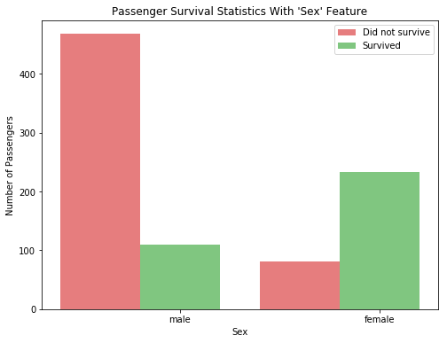

```python
outcomes = data['Survived']
data_drop = data.drop('Survived', axis = 1)
vs.survival_stats(data_drop, outcomes, 'Sex')
```

```python
d = {'Total':pd.Series([len(female),len(male)], index = ['female', 'male'] ),\
     'Survived' : (len(fm_sur), len(m_sur)),\
     'Not Survived': (len(fm_not_sur), len(m_not_sur)),\
     'Survive rate': (len(fm_sur)/float(len(female)) , len(m_sur)/float(len(male)))}
pd.DataFrame(d)
```

|  | Not Survived | Survive rate | Survived | Total |
| --- | --- | --- | --- | --- |
| female | 81 | 0.742038 | 233 | 314 |
| male | 468 | 0.188908 | 109 | 577 |

From the table above, we can conclude that females are more likely to be survived because the survive rate is almost four times of that of males. Note that the total number of females are much less than that of the males, but the number of survivals are more than double that of males.

### Age Group

[ go back to the top ]

There are 177 missing values in variable 'Age'. In this case, we simply filtered out the missing values for analysis as we could not infer from the other information to find what the missing value would be. The oldest people onboard is 80 years old.

```python
print("Number of data points with Age information: ", len(data) - len(data.Age.dropna()))
```

[output not shown]

```python
print("Maximum Age: ", max(data.Age.dropna()))
```

```
Maximum Age:  80.0
```

We saw already that gender plays an important role to be a survivor, and females have higher survival rate than males. Let's group the survivors by sex and see how suverviors' age distribution compares to that of victims.

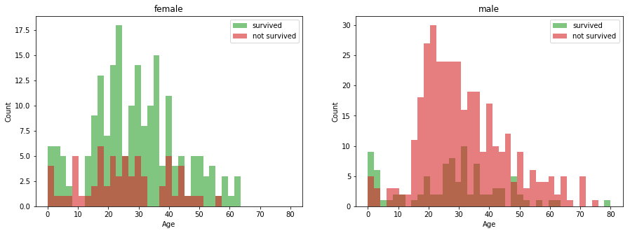

```python
bins = np.linspace(0, 80, 40)
fig = plt.figure(figsize=(15, 5))

plt.subplot(1, 2, 1)
plt.hist(fm_sur.Age.dropna(), bins, color = '#2ca02c', alpha=0.6, label='survived')
plt.hist(fm_not_sur.Age.dropna(), bins, color = '#d62728', alpha=0.6, label='not survived')
plt.xlabel('Age')
plt.ylabel('Count')
plt.title('female')
plt.legend(loc='upper right')

plt.subplot(1, 2, 2)
plt.hist(m_sur.Age.dropna(), bins, color = '#2ca02c', alpha=0.6, label='survived')
plt.hist(m_not_sur.Age.dropna(), bins, color = '#d62728',  alpha=0.6, label='not survived')
plt.xlabel('Age')
plt.ylabel('Count')
plt.title('male')
plt.legend(loc='upper right')
plt.show()
```

### Children vs. Others

[ go back to the top ]

Are childern and mothers more likely to be survived than others? Based on the information available, we define a child as a person under 18 years old and a mother is a person who is 1) a female, 2) over 18, 3) does not have the title ‘Miss’ and 4) has more than 0 children onboard.

```python
child = data.loc[(data.Parch > 0) & (data.Age < 18)]
data['Title'] = data.Name.apply(lambda x: x[x.find(', ') +2 : x.find('.')])
mother = data.loc[(data.Sex == 'female') & (data.Parch > 0) & (data.Age > 18) & (data.Title != 'Miss')]
```

```python
d = {'Total':pd.Series([len(child),len(mother)], index = ['child', 'mother'] ),\
     'Survived' : (len(child[child.Survived == 1]), len(mother[mother.Survived == 1])),\
     'Not Survived': (len(child[child.Survived == 0]), len(mother[mother.Survived == 0])),\
     'Survival rate': (len(child[child.Survived == 1])/float(len(child)) , \
                      len(mother[mother.Survived == 1])/float(len(mother)))}
pd.DataFrame(d)
```

|  | Not Survived | Survival rate | Survived | Total |
| --- | --- | --- | --- | --- |
| child | 36 | 0.555556 | 45 | 81 |
| mother | 15 | 0.711538 | 37 | 52 |

This table above makes it pretty clear that monthers have much higher survivor rate than others. Being a child does not hurt, as more than half of kids have survived.

### Ticket Price

[ go back to the top ]

Let's examine whether there is a difference between the fare survivors paied and that victims paied.

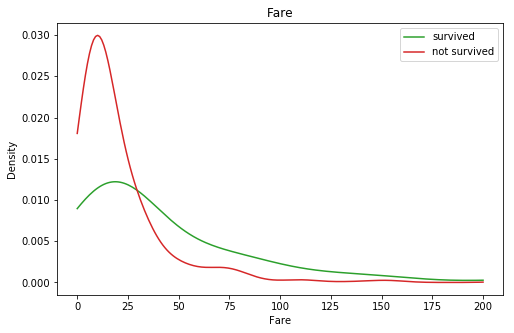

```python
from scipy.stats import gaussian_kde
density1 = gaussian_kde(sur.Fare)
density2 = gaussian_kde(nsur.Fare)

fig = plt.figure(figsize=(8, 5))
xs = np.linspace(0,200,200)
plt.plot(xs,density1(xs),color = '#2ca02c', label = 'survived')
plt.plot(xs,density2(xs),color = '#d62728', label='not survived')
plt.xlabel('Fare')
plt.ylabel('Density')
plt.title('Fare')
plt.legend(loc='upper right')
plt.show()
```

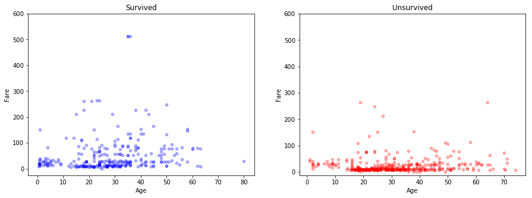

```python
fig = plt.figure(figsize=(15, 5))

plt.subplot(1, 2, 1)
plt.scatter(sur.Age , sur.Fare ,s=20, c= 'blue',marker='o', alpha = 0.3,label = 'Survived');
# plt.scatter(nsur.Age , nsur.Fare ,s=10, c= 'blue',marker='^', alpha = 0.3,label = 'Unsurvived');
plt.xlabel("Age")
plt.ylabel('Fare')
plt.title('Survived')
plt.yticks(range(0,650,100))

plt.subplot(1, 2, 2)
plt.scatter(nsur.Age , nsur.Fare ,s=20, c= 'red',marker='o', alpha = 0.3,label = 'Unsurvived');
plt.xlabel("Age")
plt.ylabel('Fare')
plt.title('Unsurvived')
plt.yticks(range(0,650,100))
plt.show()
```

Both survivors and victims cluster around age group twenties to thirties. It is also clear that kid under 10 years old are more likely to be survived. In addition, the fares that survivors paid are more spread while fares that victims paid are more aggregated at lower prices, this confirmed our observation before that people who paied more are more likely to be survived. In fact, the highest fare that non survivors paid is a around 270 £, while passagers who paid more than that are all survived.

### Ticket Class

[ go back to the top ]

It is known that Titanic carried some of the wealthiest people in the world, and we alreay knew that people who paid more are more likely to be survived from the above analysis. It is thus interesting to know the difference of survival rate between difference ticket classes.

```python
pclass = pd.concat([pd.DataFrame(data.Pclass.value_counts()),\
                    pd.DataFrame(sur.Pclass.value_counts()), \
                    pd.DataFrame(nsur.Pclass.value_counts())],axis = 1).reset_index()
pclass.columns = ['class','total','survived','non_survived']
```

```python
pclass['survival_rate'] = pclass.survived / pclass.total
pclass
```

|  | class | total | survived | non_survived | survival_rate |
| --- | --- | --- | --- | --- | --- |
| 0 | 1 | 216 | 136 | 80 | 0.629630 |
| 1 | 2 | 184 | 87 | 97 | 0.472826 |
| 2 | 3 | 491 | 119 | 372 | 0.242363 |

Therefore, first class passengers got priority to be saved when facing disasters. The survival rate is highest among first class passengers while passengers from third ticket class suffer from much lower survival rate.

### Families vs. Singletons

[ go back to the top ]

The last question we want to look at is whether singletons are more likely to survive than people have families on board. First, we’re going to make a family size variable based on number of siblings/spouse(s) and number of children/parents.

```python
sur.loc[:,'family'] = sur.loc[:,'Parch'] + sur.loc[:,'SibSp']
nsur.loc[:,'family'] = nsur.loc[:,'Parch'] + nsur.loc[:,'SibSp']
```

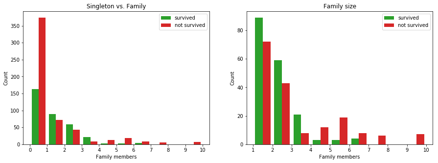

```python
fig = plt.figure(figsize=(15, 5))
bins = np.linspace(0,10,11)

plt.subplot(1, 2, 1)
plt.hist((sur['family'], nsur['family']), bins, color=['#2ca02c','#d62728'], label=("survived", "not survived"))
plt.xlabel('Family members')
plt.ylabel('Count')
plt.xticks(range(11))
plt.title('Singleton vs. Family')
plt.legend(loc='upper right')

bins2 = np.linspace(1,10,10)
plt.subplot(1, 2, 2)
plt.hist((sur[sur.family >= 1].family, nsur[nsur.family >= 1].family), bins2,  color=['#2ca02c','#d62728'], label = ("survived", "not survived"))
plt.xlabel('Family members')
plt.ylabel('Count')
plt.title('Family size')
plt.xticks(range(1,11))
plt.legend(loc='upper right')
plt.show()
```

The chart on the left shows that the most common victims are sigletons. More than half sigletons are victims. The figure on the right examines people who has families a little closer: people who have small families, such as families with two to four family members are more likely to survive, while people who have large families, meaning more than five members are more likely to be victims. To summarize, there’s a survival penalty among singletons and large families, but a benefit for customers in small families.

## Making Predictions

[ go back to the top ]

We're interested in the outcome of survival for each passenger or crew member, we can remove the **Survived** feature from this dataset and store it as its own separate variable `outcomes`. We will use these outcomes as our prediction targets.

```python
# Store the 'Survived' feature in a new variable and remove it from the dataset
# Show the new dataset with 'Survived' removed
display(data_drop.head())
```

|  | PassengerId | Pclass | Name | Sex | Age | SibSp | Parch | Ticket | Fare | Cabin | Embarked |
| --- | --- | --- | --- | --- | --- | --- | --- | --- | --- | --- | --- |
| 0 | 1 | 3 | Braund, Mr. Owen Harris | male | 22.0 | 1 | 0 | A/5 21171 | 7.2500 | NaN | S |
| 1 | 2 | 1 | Cumings, Mrs. John Bradley (Florence Briggs Th... | female | 38.0 | 1 | 0 | PC 17599 | 71.2833 | C85 | C |
| 2 | 3 | 3 | Heikkinen, Miss. Laina | female | 26.0 | 0 | 0 | STON/O2. 3101282 | 7.9250 | NaN | S |
| 3 | 4 | 1 | Futrelle, Mrs. Jacques Heath (Lily May Peel) | female | 35.0 | 1 | 0 | 113803 | 53.1000 | C123 | S |
| 4 | 5 | 3 | Allen, Mr. William Henry | male | 35.0 | 0 | 0 | 373450 | 8.0500 | NaN | S |

### Accuracy Score

[ go back to the top ]

The very same sample of the RMS Titanic data now shows the **Survived** feature removed from the DataFrame. Note that `data` (the passenger data) and `outcomes` (the outcomes of survival) are now *paired*. That means for any passenger `data.loc[i]`, they have the survival outcome `outcomes[i]`.

To measure the performance of our predictions, we need a metric to score our predictions against the true outcomes of survival. Since we are interested in how *accurate* our predictions are, we will calculate the proportion of passengers where our prediction of their survival is correct.

```python
def accuracy_score(truth, pred):
    """ Returns accuracy score for input truth and predictions. """

    # Ensure that the number of predictions matches number of outcomes
    if len(truth) == len(pred):

        # Calculate and return the accuracy as a percent
        return "Predictions have an accuracy of {:.2f}%.".format((truth == pred).mean()*100)

    else:
        return "Number of predictions does not match number of outcomes!"

# Test the 'accuracy_score' function
# predictions = pd.Series(np.ones(5, dtype = int))
# print(accuracy_score(outcomes[:5], predictions))
```

### Model 1

[ go back to the top ]

Examining the survival statistics, a large majority of males did not survive the ship sinking. However, a majority of females *did* survive the ship sinking. Let's build our prediction: If a passenger was female, then we will predict that they survived. Otherwise, we will predict the passenger did not survive.

```python
def predictions_1(data):
    """ Model with one feature:
            - Predict a passenger survived if they are female. """

    predictions = []
    for _, passenger in data.iterrows():
        # Remove the 'pass' statement below
        # and write your prediction conditions here
        if passenger["Sex"] == "female":
            predictions.append(1)
        else:
            predictions.append(0)

    # Return our predictions
    return pd.Series(predictions)

# Make the predictions
predictions = predictions_1(data)
```

```python
print(accuracy_score(outcomes, predictions))
```

```
Predictions have an accuracy of 78.68%.
```

### Model 2

[ go back to the top ]

Now, let's consider using an additional feature to see if we can further improve our predictions. For example, consider all of the male passengers aboard the RMS Titanic: Can we find a subset of those passengers that had a higher rate of survival? Let's start by looking at the Age of each male, by again using the survival_stats function. This time, we'll use a fourth parameter to filter out the data so that only passengers with the Sex 'male' will be included.

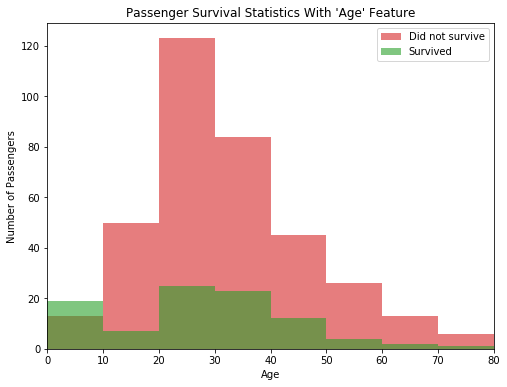

```python
vs.survival_stats(data_drop, outcomes, 'Age', ["Sex == 'male'"])
```

Examining the survival statistics, the majority of males younger than 10 survived the ship sinking, whereas most males age 10 or older *did not survive* the ship sinking. Let's continue to build on our previous prediction: If a passenger was female, then we will predict they survive. If a passenger was male and younger than 10, then we will also predict they survive. Otherwise, we will predict they do not survive.

```python
def predictions_2(data):
    """ Model with two features:
            - Predict a passenger survived if they are female.
            - Predict a passenger survived if they are male and younger than 10. """

    predictions = []
    for _, passenger in data.iterrows():
        # Remove the 'pass' statement below
        # and write your prediction conditions here
        if passenger["Sex"] == "female":
            predictions.append(1)
        elif (passenger["Sex"] == "male") and (passenger["Age"] < 10):
            predictions.append(1)
        else:
            predictions.append(0)

    # Return our predictions
    return pd.Series(predictions)

# Make the predictions
predictions = predictions_2(data)
```

```python
print(accuracy_score(outcomes, predictions))
```

```
Predictions have an accuracy of 79.35%.
```

Accuracy increased less than 1% if we assume males younger than 10 survived. Adding the feature **Age** as a condition in conjunction with **Sex** improves the accuracy by a small margin more than with simply using the feature **Sex** alone.

### Final Model

[ go back to the top ]

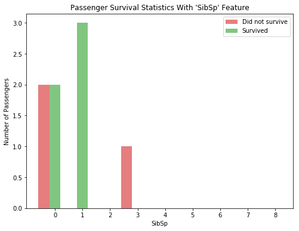

```python
vs.survival_stats(data_drop, outcomes, 'SibSp', ["Sex == 'male'", "Parch == 2", "Pclass == 1"])
```

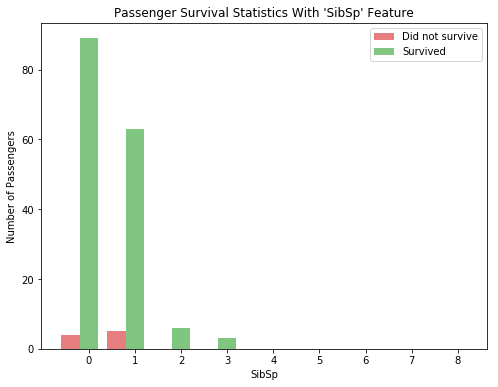

```python
# female
vs.survival_stats(data_drop, outcomes, 'SibSp', ["Sex == 'female'", "Pclass < 3"])
```

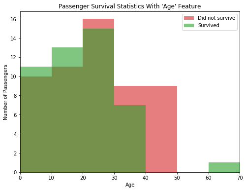

```python
vs.survival_stats(data_drop, outcomes, 'Age', ["Sex == 'female'", "Pclass == 3"])
```

```python
def predictions_3(data):
    """ Model with multiple features. Makes a prediction with an accuracy of at least 80%. """

    predictions = []
    for _, passenger in data.iterrows():
        if passenger["Sex"] == "female":
            if (passenger["Pclass"] < 3):
                predictions.append(1)
            else:
                if (passenger["Age"] >= 40) and (passenger["Age"] < 60):
                    predictions.append(0)
                else:
                    predictions.append(1)
        else:
            if (passenger["Age"] < 10):
                predictions.append(1)
            elif (passenger["Parch"] == 2) and (passenger["Pclass"] == 1) and (passenger["SibSp"] == 1):
                predictions.append(1)
            else:
                predictions.append(0)

    # Return our predictions
    return pd.Series(predictions)

# Make the predictions
predictions = predictions_3(data)
```

```python
print(accuracy_score(outcomes, predictions))
```

```
Predictions have an accuracy of 80.58%.
```

## Conclusion

[ go back to the top ]

### Limitation

[ go back to the top ]

This analysis is limited by the sample size of the data and the available information of each passagers. We have a total of 891 data points, but 177 of them do not have age information. Despite the data limitations, we gained some insights from analyzing this dataset:

### Prediction

[ go back to the top ]

After several iterations of exploring and conditioning on the data, we have built a useful algorithm for predicting the survival of each passenger aboard the RMS Titanic. The technique applied in this project is a manual implementation of a simple machine learning model, the *decision tree*. A decision tree splits a set of data into smaller and smaller groups (called *nodes*), by one feature at a time. Each time a subset of the data is split, our predictions become more accurate if each of the resulting subgroups are more homogeneous (contain similar labels) than before. The advantage of having a computer do things for us is that it will be more exhaustive and more precise than our manual exploration above. [This link](http://www.r2d3.us/visual-intro-to-machine-learning-part-1/) provides another introduction into machine learning using a decision tree.

A decision tree is just one of many models that come from *supervised learning*. In supervised learning, we attempt to use features of the data to predict or model things with objective outcome labels. That is to say, each of our data points has a known outcome value, such as a categorical, discrete label like `'Survived'`, or a numerical, continuous value like predicting the price of a house.